# REPRODUCIBLE RESEARCH: PEER ASSIGNMENT 1

This document concerns the generation of statistics and the processing of data about walking activity, measured as number of steps taken in 5-minute intervals, monitored ininterruptly for two months in a single individual.

## Loading and preprocessing the data

Once you make sure you are working in the directory containing the data (file “activity.zip”), load the data into the variable *steps*:

```r
steps <- read.csv(unzip("activity.zip"))
```

Next, we should convert the data in the *date* column into date format:

```r
steps$date <- as.Date(steps$date)
```

## What is mean total number of steps taken per day?

We will be using the package **dplyr** to generate summaries. First, we will generate a histogram with the *total number of steps taken per day*:

```r
library(dplyr)
prob1 <- steps %>% group_by(date) %>% summarise(sum(steps, na.rm=T))
```

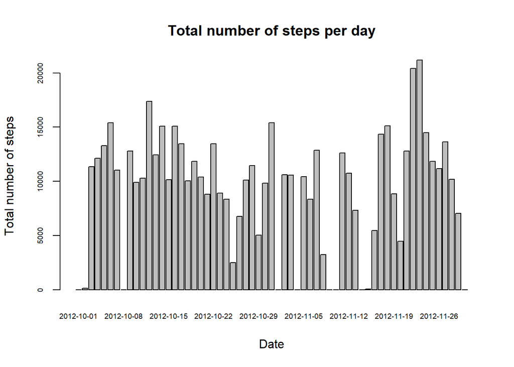

```r
barplot(prob1$`sum(steps, na.rm = T)`, names.arg = prob1$date, main = "Total number of steps per day", xlab = "Date", ylab = "Total number of steps", cex.axis=0.6, cex.names=0.6)
```

Next, let us check the *mean* and *median* of these totals:

```r
mean(prob1$`sum(steps, na.rm = T)`)
```

```
## [1] 9354.23
```

```r
median(prob1$`sum(steps, na.rm = T)`)
```

```
## [1] 10395
```

## What is the average daily activity pattern?

Let us see the *number of steps taken averaged by interval*:

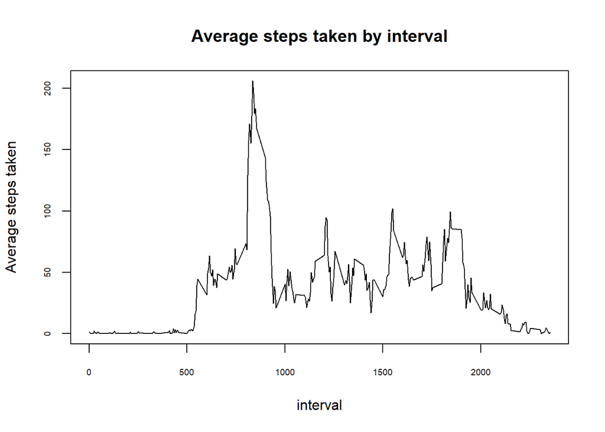

```r
prob2 <- steps %>% group_by(interval) %>% summarise(mean(steps, na.rm=T))
plot(prob2, type="l", cex.axis = 0.6, ylab = "Average steps taken", main = "Average steps taken by interval")
```

Which interval contains the *maximum average*?

```r
prob2$interval[which.max(prob2$`mean(steps, na.rm = T)`)]
```

```
## [1] 835
```

## Imputing missing values

How many NA’s are there in the original dataset?

```r
sum(is.na(steps$steps))
```

```
## [1] 2304
```

We will fill these NA values with the *mean of steps for that interval* (which is already stored in the variable *prob2*), and store the result in a new dataset called *steps_full*.

First, let us *arrange the original dataset grouped by interval*, which facilitates a step further on:

```r
prob3 <- steps %>% arrange(.by_group=interval)
```

Now let us build a vector reporting *how many times each interval* is included in the dataset (which equals how many days each interval had information for):

```r
n <- as.vector(table(steps$interval))
```

We now build another vector containing the *mean of steps for that interval* repeated *n* times (one time for each date):

```r
vector <- rep(prob2$`mean(steps, na.rm = T)`, n)
```

Next, let us generate a vector stating the *number of the row containing an NA* in the column *step*. Then, let us change that value for the one in the *vector* variable corresponding to that same row:

```r
which <- which(is.na(prob3$steps))
prob3$steps[which] <- vector[which]
```

Finally, only because we are perfectionits, let us *rearrange the dataset to the original arrangement* (sorted by date):

```r
prob3 %>% arrange(.by_group = date) -> steps_full
```

Let us repeat the histogram drawn in the first problem, but now with the imputed missing data:

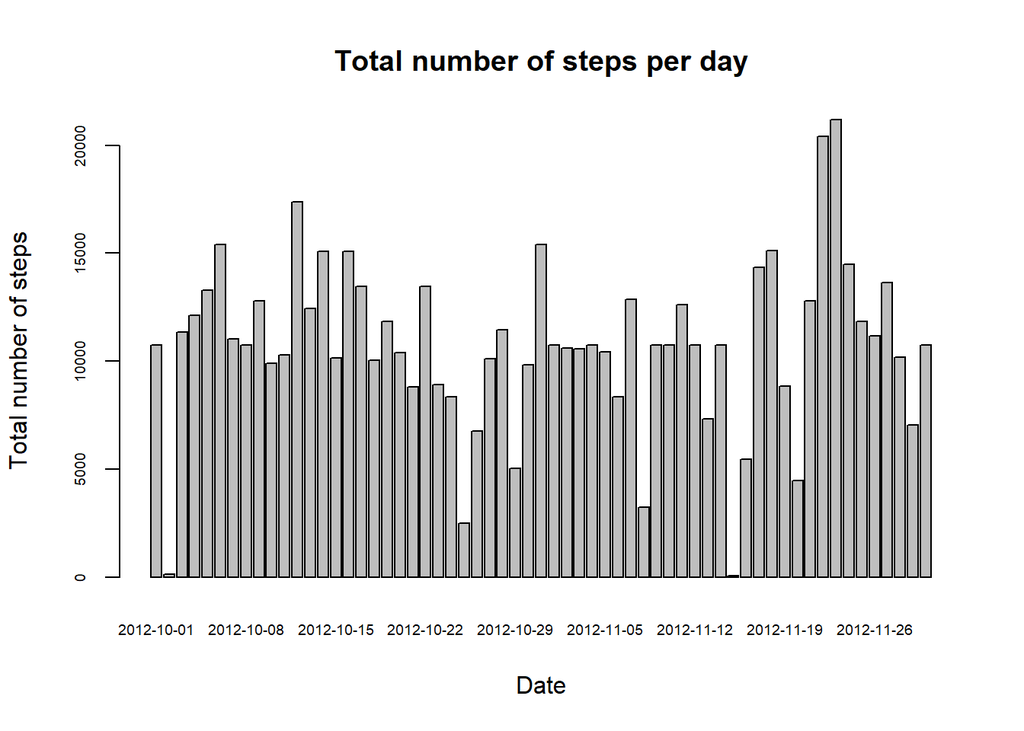

```r
prob3b <- steps_full %>% group_by(date) %>% summarise(sum(steps))
barplot(prob3b$`sum(steps)`, names.arg = prob3b$date, main = "Total number of steps per day", xlab = "Date", ylab = "Total number of steps", cex.axis=0.6, cex.names=0.6)
```

Let us check the *mean* and the *median* for this new dataset:

```r
mean(prob3b$`sum(steps)`)
```

```
## [1] 10766.19
```

```r
median(prob3b$`sum(steps)`)
```

```
## [1] 10766.19
```

Both values are higher than when ignoring missing values.

## Are there differences in activity patterns between weekdays and weekends?

First we should create a vector to represent if the data in each row concerns a weekday or a weekend. We will be adding this vector to a new column called *which_day*. (I apologize for the weekday names in Portuguese, I **could not** change this feture >:( ).Then we will group the day by *which_day*, then by *interval*, and summarize as a *mean*.

```r
prob4 <- steps_full
prob4$which_day <- ifelse(weekdays(prob4$date) %in% c("sábado", "domingo"), "weekend", "weekday")
prob4b <- prob4 %>% group_by(which_day, interval) %>% summarise(mean(steps))
```

We will now generate a plot of the *means* by *interval*, separated by *which_day*.

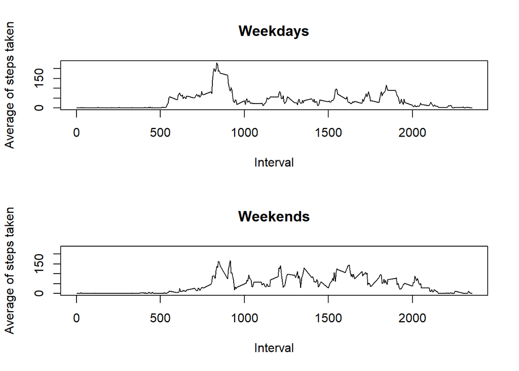

```r
par(mfrow=c(2,1))
plot(prob4b$interval[prob4b$which_day == "weekday"], prob4b$`mean(steps)`[prob4b$which_day == "weekday"], type = "l", ylim = c(0, max(prob4b$`mean(steps)`)), xlab = "Interval", ylab = "Average of steps taken", main = "Weekdays")
plot(prob4b$interval[prob4b$which_day == "weekend"], prob4b$`mean(steps)`[prob4b$which_day == "weekend"], type = "l", ylim = c(0, max(prob4b$`mean(steps)`)),xlab = "Interval", ylab = "Average of steps taken", main = "Weekends")
```

Since we set the y-axis to cover the same limit values, we can be sure there is a difference between the activity patterns in weekdays and weekends.